# Project 3 Regression

## Predicting House Sale Prices

Predicting the amount a house will sell for on the market is an important task within the market. Many Realtors often search up different aspects such as neighborhood, square footage, and more to see what to price a house in. This challenge while relevant is a difficult one as the market is always changing.

The dataset that we are using can be found here. It comes from a Kaggle competition that focuses on learning regression techniques. The Dataset offers 79 variables that we can play around with ranging from Lot Size, neighborhoods, the year the house was built, ratings, the year sold, and more. It showcases many different values that are often considered when determining the sale price of a house. As someone who has a close friend as a realtor, these models are becoming more and more often within the space as they help people determine their house value at any time.

Regression is the focus of this assignment and we will be exploring what that means and how we use it throughout the different number of experiments we will be tackling.

## What is Regression and How Does it Work?

Regression is a Machine Learning training method for models that allows for predicting a continuous value based upon several features the model is aware of. For example, a car price could be predicted depending on different values provided, such as Make, Year, Brand, Gas Mileage, Current Mileage, and more. Unlike classification, regression involves looking at and predicting a range of different values instead of specific values.

In this case, we will be looking at House Prices. We will use a mix of different regression methods but focusing on Linear Regression. This is where it models the target variable as a linear value of different features, minimizing error. However, there are more techniques that can be used like Ridge Regression (which we use in Experiment 2) and Random Forst Regression (which we use in Experiment 3)

Using these different methods, we will explore different values and different features and techniques we can use to improve our models.

```python
%pip install numpy pandas matplotlib seaborn sklearn
```

[output not shown]

[output not shown]

```python
# Imports
import pandas as pd
import numpy as np
import matplotlib.pyplot as plt
import seaborn as sns
from sklearn.feature_selection import VarianceThreshold
from sklearn.model_selection import train_test_split
from sklearn.linear_model import LinearRegression, Ridge
from sklearn.ensemble import RandomForestRegressor
from sklearn.metrics import mean_squared_error, mean_absolute_error, r2_score

train_df = pd.read_csv("./train.csv");
```

```python
train_df.head()
```

|  | Id | MSSubClass | MSZoning | LotFrontage | LotArea | Street | Alley | LotShape | LandContour | Utilities | ... | PoolArea | PoolQC | Fence | MiscFeature | MiscVal | MoSold | YrSold | SaleType | SaleCondition | SalePrice |
| --- | --- | --- | --- | --- | --- | --- | --- | --- | --- | --- | --- | --- | --- | --- | --- | --- | --- | --- | --- | --- | --- |
| 0 | 1 | 60 | RL | 65.0 | 8450 | Pave | NaN | Reg | Lvl | AllPub | ... | 0 | NaN | NaN | NaN | 0 | 2 | 2008 | WD | Normal | 208500 |
| 1 | 2 | 20 | RL | 80.0 | 9600 | Pave | NaN | Reg | Lvl | AllPub | ... | 0 | NaN | NaN | NaN | 0 | 5 | 2007 | WD | Normal | 181500 |
| 2 | 3 | 60 | RL | 68.0 | 11250 | Pave | NaN | IR1 | Lvl | AllPub | ... | 0 | NaN | NaN | NaN | 0 | 9 | 2008 | WD | Normal | 223500 |
| 3 | 4 | 70 | RL | 60.0 | 9550 | Pave | NaN | IR1 | Lvl | AllPub | ... | 0 | NaN | NaN | NaN | 0 | 2 | 2006 | WD | Abnorml | 140000 |
| 4 | 5 | 60 | RL | 84.0 | 14260 | Pave | NaN | IR1 | Lvl | AllPub | ... | 0 | NaN | NaN | NaN | 0 | 12 | 2008 | WD | Normal | 250000 |

5 rows × 81 columns

```python
print(train_df.info())
```

```
<class 'pandas.core.frame.DataFrame'>
RangeIndex: 1460 entries, 0 to 1459
Data columns (total 81 columns):
 #   Column         Non-Null Count  Dtype
---  ------         --------------  -----
 0   Id             1460 non-null   int64
 1   MSSubClass     1460 non-null   int64
 2   MSZoning       1460 non-null   object
 3   LotFrontage    1201 non-null   float64
 4   LotArea        1460 non-null   int64
 5   Street         1460 non-null   object
 6   Alley          91 non-null     object
 7   LotShape       1460 non-null   object
 8   LandContour    1460 non-null   object
 9   Utilities      1460 non-null   object
```

[output cut: 74 more lines]

```python
print(train_df.describe())
```

```
                Id   MSSubClass  LotFrontage        LotArea  OverallQual  \
count  1460.000000  1460.000000  1201.000000    1460.000000  1460.000000
mean    730.500000    56.897260    70.049958   10516.828082     6.099315
std     421.610009    42.300571    24.284752    9981.264932     1.382997
min       1.000000    20.000000    21.000000    1300.000000     1.000000
25%     365.750000    20.000000    59.000000    7553.500000     5.000000
50%     730.500000    50.000000    69.000000    9478.500000     6.000000
75%    1095.250000    70.000000    80.000000   11601.500000     7.000000
max    1460.000000   190.000000   313.000000  215245.000000    10.000000

       OverallCond    YearBuilt  YearRemodAdd   MasVnrArea   BsmtFinSF1  ...  \
count  1460.000000  1460.000000   1460.000000  1452.000000  1460.000000  ...
mean      5.575342  1971.267808   1984.865753   103.685262   443.639726  ...
std       1.112799    30.202904     20.645407   181.066207   456.098091  ...
min       1.000000  1872.000000   1950.000000     0.000000     0.000000  ...
25%       5.000000  1954.000000   1967.000000     0.000000     0.000000  ...
50%       5.000000  1973.000000   1994.000000     0.000000   383.500000  ...
75%       6.000000  2000.000000   2004.000000   166.000000   712.250000  ...
max       9.000000  2010.000000   2010.000000  1600.000000  5644.000000  ...

        WoodDeckSF  OpenPorchSF  EnclosedPorch    3SsnPorch  ScreenPorch  \
count  1460.000000  1460.000000    1460.000000  1460.000000  1460.000000
mean     94.244521    46.660274      21.954110     3.409589    15.060959
std     125.338794    66.256028      61.119149    29.317331    55.757415
min       0.000000     0.000000       0.000000     0.000000     0.000000
25%       0.000000     0.000000       0.000000     0.000000     0.000000
50%       0.000000    25.000000       0.000000     0.000000     0.000000
75%     168.000000    68.000000       0.000000     0.000000     0.000000
max     857.000000   547.000000     552.000000   508.000000   480.000000

          PoolArea       MiscVal       MoSold       YrSold      SalePrice
count  1460.000000   1460.000000  1460.000000  1460.000000    1460.000000
mean      2.758904     43.489041     6.321918  2007.815753  180921.195890
std      40.177307    496.123024     2.703626     1.328095   79442.502883
min       0.000000      0.000000     1.000000  2006.000000   34900.000000
25%       0.000000      0.000000     5.000000  2007.000000  129975.000000
50%       0.000000      0.000000     6.000000  2008.000000  163000.000000
75%       0.000000      0.000000     8.000000  2009.000000  214000.000000
max     738.000000  15500.000000    12.000000  2010.000000  755000.000000

[8 rows x 38 columns]
```

## Lets check for any missing values

```python
# Lets check for missing values.
missing = train_df.isnull().sum().sort_values(ascending=False)
missing = missing[missing > 0]
print("\nMissing Values:\n", missing)
```

```
Missing Values:
 PoolQC          1453
MiscFeature     1406
Alley           1369
Fence           1179
MasVnrType       872
FireplaceQu      690
LotFrontage      259
GarageQual        81
GarageFinish      81
GarageType        81
GarageYrBlt       81
GarageCond        81
BsmtFinType2      38
BsmtExposure      38
BsmtCond          37
BsmtQual          37
BsmtFinType1      37
MasVnrArea         8
Electrical         1
dtype: int64
```

As we can see we have many missing values when taking a look at `PoolQC`, `MiscFeature`, `Alley`, and `Fence` these values are missing in over 50%. We will remove them as well as any others that fall into the more or equal to 50% range, after that we will fill in any other remaining missing values with the median to ensure an overall good model.

```python
# The try finally is just to prevent errors while running.
try:
    train_df = train_df.drop(train_df.columns[(train_df.isnull().sum() / train_df.shape[0] >= 0.50)], axis=1)
finally:
    missing = train_df.isnull().sum().sort_values(ascending=False)
    missing = missing[missing > 0]
    print("Missing Values:\n", missing)
```

```
Missing Values:
 FireplaceQu     690
LotFrontage     259
GarageYrBlt      81
GarageQual       81
GarageFinish     81
GarageType       81
GarageCond       81
BsmtFinType2     38
BsmtExposure     38
BsmtQual         37
BsmtCond         37
BsmtFinType1     37
MasVnrArea        8
Electrical        1
dtype: int64
```

```python
# We want to fill numerical valeus with the median
numCols = train_df.select_dtypes(include=["int64", "float64"]).columns #
train_df[numCols] = train_df[numCols].fillna(train_df[numCols].median())

# Now we want to remove colummns that wont serve a purpose to use. Non-Infomative colums that we want removed from the training.
train_df = train_df.drop(['Id', 'MSZoning', 'MSSubClass', 'LandSlope', 'RoofMatl', 'MoSold', 'LotShape', 'BsmtCond', 'LandContour', 'GarageYrBlt', 'YearRemodAdd', 'Street', 'Utilities', 'GarageCond', 'Condition1', 'Condition2', 'Electrical', 'Functional', 'Heating', 'CentralAir'], axis=1)
# Now we want to encode the categorial values we need. The values arent numbered, and we want to be able for them to be a vlue. So we will One-hot encode the values so they can be used in modeling.
train_df = pd.get_dummies(train_df, columns=train_df.select_dtypes(include=["object"]).columns, drop_first=True, dtype=int);
train_df.head()
```

|  | LotFrontage | LotArea | OverallQual | OverallCond | YearBuilt | MasVnrArea | BsmtFinSF1 | BsmtFinSF2 | BsmtUnfSF | TotalBsmtSF | ... | SaleType_ConLI | SaleType_ConLw | SaleType_New | SaleType_Oth | SaleType_WD | SaleCondition_AdjLand | SaleCondition_Alloca | SaleCondition_Family | SaleCondition_Normal | SaleCondition_Partial |
| --- | --- | --- | --- | --- | --- | --- | --- | --- | --- | --- | --- | --- | --- | --- | --- | --- | --- | --- | --- | --- | --- |
| 0 | 65.0 | 8450 | 7 | 5 | 2003 | 196.0 | 706 | 0 | 150 | 856 | ... | 0 | 0 | 0 | 0 | 1 | 0 | 0 | 0 | 1 | 0 |
| 1 | 80.0 | 9600 | 6 | 8 | 1976 | 0.0 | 978 | 0 | 284 | 1262 | ... | 0 | 0 | 0 | 0 | 1 | 0 | 0 | 0 | 1 | 0 |
| 2 | 68.0 | 11250 | 7 | 5 | 2001 | 162.0 | 486 | 0 | 434 | 920 | ... | 0 | 0 | 0 | 0 | 1 | 0 | 0 | 0 | 1 | 0 |
| 3 | 60.0 | 9550 | 7 | 5 | 1915 | 0.0 | 216 | 0 | 540 | 756 | ... | 0 | 0 | 0 | 0 | 1 | 0 | 0 | 0 | 0 | 0 |
| 4 | 84.0 | 14260 | 8 | 5 | 2000 | 350.0 | 655 | 0 | 490 | 1145 | ... | 0 | 0 | 0 | 0 | 1 | 0 | 0 | 0 | 1 | 0 |

5 rows × 171 columns

### Correlated Features (Top 15)

Some Insights:

- `OverallQual` - This is the leading correlated feature, showcasing that the overall quality of the house is the most important.
- `GrLivArea` - Showcases that a larger living area is a strong method on predicting a sale value.
- `GarageCars` - The size of a garage showcases its correlation being strong with the sale value.
- `YearBuilt` - Showcases a rather strong correlation for our sale price. As depending on how old a house is, can easily showcase value due to possible renovations needed.

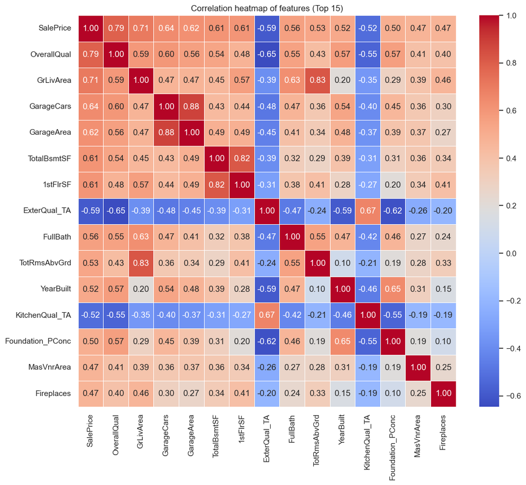

```python
sns.set_theme(style="whitegrid")

# Correlation heatmap
corr_matrix = train_df.corr()
top_corr_features = corr_matrix["SalePrice"].abs().sort_values(ascending=False)[0:15] # Due to too many features, we want to just get the top ones, since its all that matters for the showcase.
plt.figure(figsize=(12, 10))
sns.heatmap(train_df[top_corr_features.index].corr(), annot=True, cmap='coolwarm', fmt='.2f', linewidths=0.5)
plt.title('Correlation heatmap of features (Top 15)')
plt.show()
```

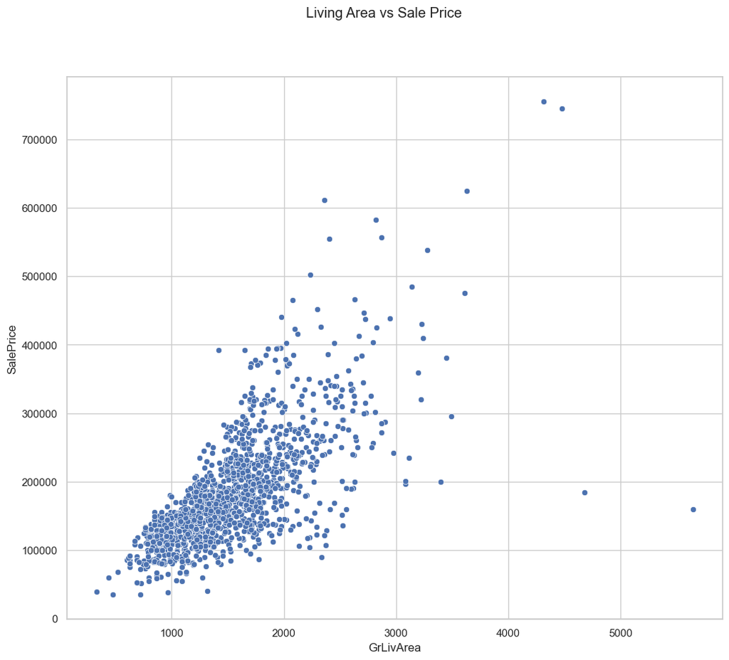

```python
plt.figure(figsize=(12, 10))
sns.scatterplot(x='GrLivArea', y='SalePrice', data=train_df)
plt.suptitle('Living Area vs Sale Price')
plt.show()
```

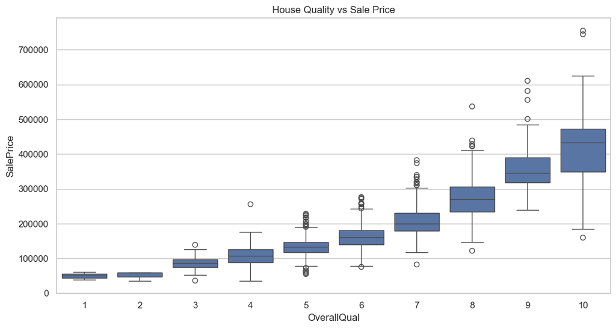

```python
plt.figure(figsize=(12,6))
sns.boxplot(x='OverallQual', y='SalePrice', data=train_df)
plt.title('House Quality vs Sale Price')
plt.show()
```

## Experiment 1: Linear Regression

### Modeling.

Since we are using the Kaggle competition, This will not be submitted so we need to split the dataset into training and testing subsets for our uses.

### Variance Threshold Feature

I wanted to try the Variance threshold, which removes features with low variance. This removes 38 features after we filter through, we use this to create our split for training and testing.

```python
X = train_df.drop('SalePrice', axis=1)
y = train_df['SalePrice']

selector = VarianceThreshold(threshold=0.01)
X_selected = selector.fit_transform(X)

print(f"Original features: {X.shape[1]}")
print(f"Features after variance threshold: {X_selected.shape[1]}")
```

```
Original features: 170
Features after variance threshold: 132
```

### Modeling

Now we create the Test and Train Split and create the Linear Regression Model

```python
X_train, X_test, y_train, y_test = train_test_split(X_selected, y, test_size=0.2, random_state=42) # We will do a 80/20 Split where 20 percent goes torwards testing.
lr = LinearRegression()
lr.fit(X_train, y_train)
```

```
LinearRegression()
```

```python
preds = lr.predict(X_test)
print(f"Linear Regression Experiement 1 Results:")
print(f"RMSE: ${np.sqrt(mean_squared_error(y_test, preds)):,.2f}")
print(f"MAE: ${mean_absolute_error(y_test, preds):,.2f}")
print(f"R²: {r2_score(y_test, preds):.3f}")
```

```
Linear Regression Experiement 1 Results:
RMSE: $30,895.02
MAE: $19,230.91
R²: 0.876
```

### Visualization

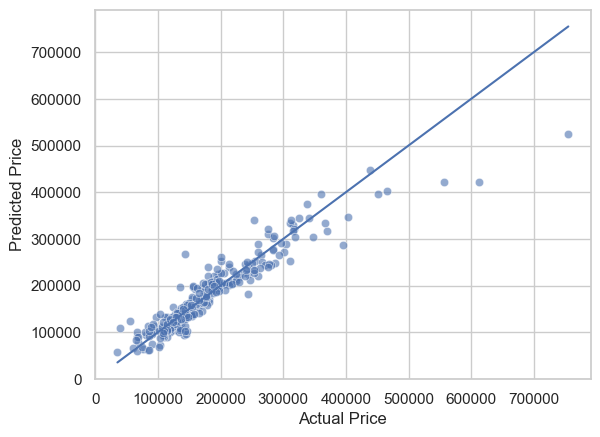

```python
sns.scatterplot(x=y_test, y=preds, alpha=0.6)
plt.plot([y_test.min(), y_test.max()], [y_test.min(), y_test.max()])
plt.ylabel("Predicted Price")
plt.xlabel("Actual Price")
plt.show()
```

## Experiment 2: Ridge Regression + More Features

For Experiment 2, I will be using Ridge Regression while also adding 2 additional features. Using the Ridge function from sklearn to train the model. While also adding Feature Scaling during Preprocessing

- `TotalSF` - The Total SF of the house which adds up the SF provided per house (`GrLivArea` + `TotalBsmtSF`)
- `HouseAge` - The age of the house (`YrSold` - `YearBuilt`)

```python
ex2_df = train_df.copy(); # Make a copy of the Train_Df Modified DF

ex2_df['TotalSF'] = ex2_df['GrLivArea']  + ex2_df['TotalBsmtSF'];
ex2_df['HouseAge'] = ex2_df['YrSold'] - ex2_df['YearBuilt']

X = ex2_df.drop('SalePrice', axis=1)
X = (X - X.mean()) / X.std() # Scale/Average the Values
y = ex2_df['SalePrice']

X_train, X_test, y_train, y_test = train_test_split(X, y, test_size=0.2, random_state=42)
ridge = Ridge(alpha=100)
ridge.fit(X_train, y_train)

preds = ridge.predict(X_test)
print(f"RMSE: ${np.sqrt(mean_squared_error(y_test, preds)):,.2f}")
print(f"MAE: ${mean_absolute_error(y_test, preds):,.2f}")
print(f"R²: {r2_score(y_test, preds):.3f}")
```

```
RMSE: $32,262.35
MAE: $19,229.14
R²: 0.864
```

### Visualization

We will use the same visualization that we used in the previous experiment. We can see that our model continues to perform.

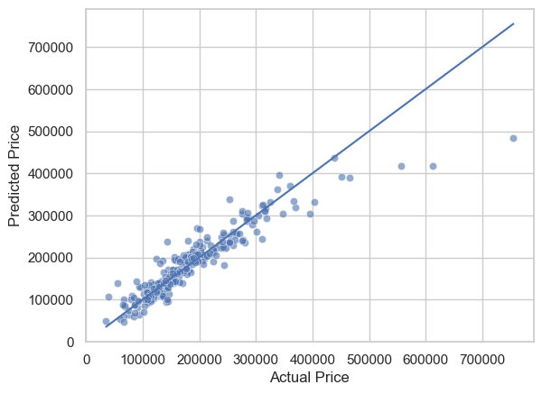

```python
sns.scatterplot(x=y_test, y=preds, alpha=0.6)
plt.plot([y_test.min(), y_test.max()], [y_test.min(), y_test.max()])
plt.ylabel("Predicted Price")
plt.xlabel("Actual Price")
plt.show()
```

### Correlated Features with Enginnerring

Some Insights:

- `OverallQual` - Continues to be a leading correlated feature followed by `GrLivArea`, `GarageCars`, and `GarageArea`
- `TotalSF` - Our added feature plays a heavy role at `.78`

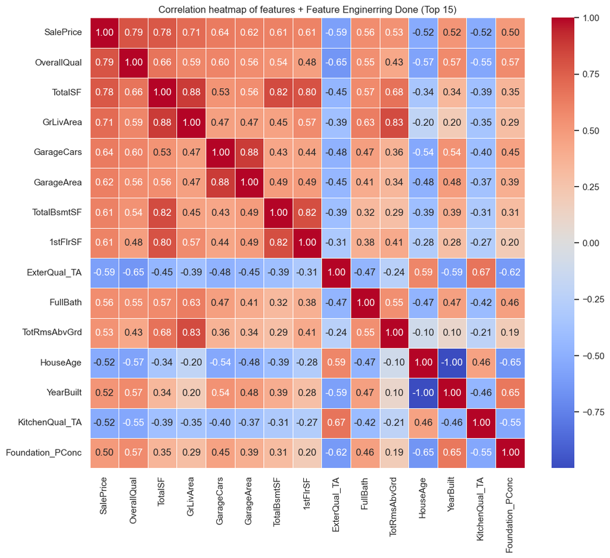

```python
# Correlation heatmap
plt.figure(figsize=(12, 10))
sns.heatmap(ex2_df[ex2_df.corr()["SalePrice"].abs().sort_values(ascending=False)[0:15].index].corr(), annot=True, cmap='coolwarm', fmt='.2f', linewidths=0.5) # Due to too many features, we want to just get the top ones, since its all that matters for the showcase.
plt.title('Correlation heatmap of features + Feature Enginerring Done (Top 15)')
plt.show()
```

For Experiment 3, I will be using Random Forest Regression

```python
ex3_df = train_df.copy();

ex3_df['TotalSF'] = ex3_df['GrLivArea']  + ex3_df['TotalBsmtSF'];
ex3_df['HouseAge'] = ex3_df['YrSold'] - ex3_df['YearBuilt']

X_selected = ex3_df.drop('SalePrice', axis=1)
y = ex3_df['SalePrice']

selector = VarianceThreshold(threshold=0.01)
X_selected = selector.fit_transform(X)

X_selected = (X_selected - X_selected.mean()) / X_selected.std() # Scale/Average the Values

X_train, X_test, y_train, y_test = train_test_split(X, y, test_size=0.2, random_state=42)

rf = RandomForestRegressor(n_estimators=100)
rf.fit(X_train, y_train)

preds = rf.predict(X_test)
print(f"RMSE: ${np.sqrt(mean_squared_error(y_test, preds)):,.2f}")
print(f"MAE: ${mean_absolute_error(y_test, preds):,.2f}")
print(f"R²: {r2_score(y_test, preds):.3f}")
```

```
RMSE: $30,253.11
MAE: $18,128.59
R²: 0.881
```

### Visualization

We will use the same visualization that we used in the previous experiment. We can see that our model continues to perform. This time even better than our previous models.

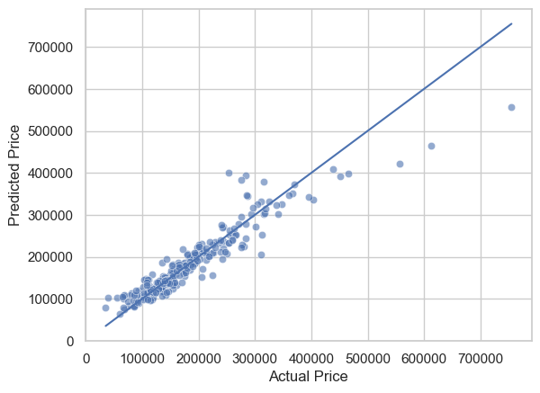

```python
sns.scatterplot(x=y_test, y=preds, alpha=0.6)
plt.plot([y_test.min(), y_test.max()], [y_test.min(), y_test.max()])
plt.ylabel("Predicted Price")
plt.xlabel("Actual Price")
plt.show()
```

### Correlated Features (Experiment 3)

Our Correlated features have pretty much stayed consistant across the board within each of our models.

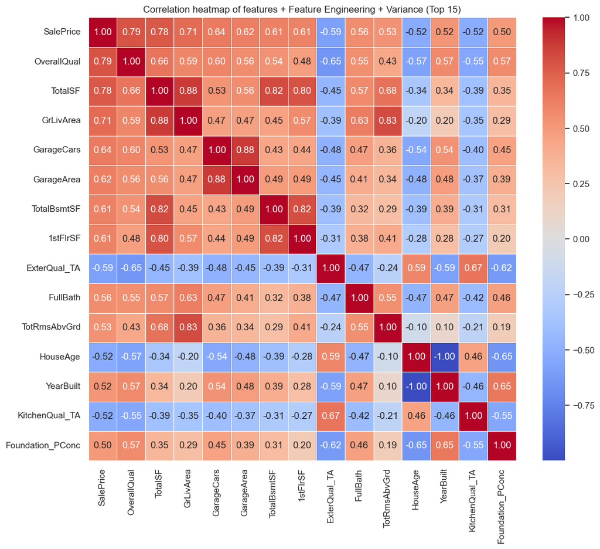

```python
# Correlation heatmap
plt.figure(figsize=(12, 10))
sns.heatmap(ex3_df[ex3_df.corr()["SalePrice"].abs().sort_values(ascending=False)[0:15].index].corr(), annot=True, cmap='coolwarm', fmt='.2f', linewidths=0.5) # Due to too many features, we want to just get the top ones, since its all that matters for the showcase.
plt.title('Correlation heatmap of features + Feature Engineering + Variance (Top 15)')
plt.show()
```

## Impact

The impact of the model can vary. The model helps drive data-driven decsioins within the Real Estate market, helping agents and buyers evaluate houses and the possible sale price of a house. By Using its key features that many homes have it can help determine pricing for everoyne. The model can also scale easliey, by implementing new data when needed.

The negatives of this model are a bit different, there is bias due to the historical data of houses. As we have seen over the past couple of years, house prices tend to get into a bubble which can lead to increased and inflated pricing over the market for a short period. Another is an overreliance on how small this model and data are. Each area in the world has its pricing, so the model has a shortcoming due to location. This model can also lead to some issues with jobs as there are jobs that require people to go out and appraise houses.

## References

Kaggle House Prices Dataset Used [here](https://www.kaggle.com/competitions/house-prices-advanced-regression-techniques/data)

Scikit Learn Linear Regression [here](https://scikit-learn.org/stable/modules/generated/sklearn.linear_model.LinearRegression.html)

Scikit Learn Documentation Overall (Too many to list) [here](https://scikit-learn.org/stable/api/index.html)